# HW1

Xinwei Zhang

2/4/2018

## P3

### (a)

```r
set.seed(1)
x = rnorm(100, mean=0, sd=1)
```

### (b)

```r
eps = rnorm(100, mean=0, sd=sqrt(0.25))
```

### (c)

```r
y = -1 + 0.5*x + eps
```

Length of y is 100. $\beta_0$ is -1, $\beta_1$ is 0.5.

### (d)

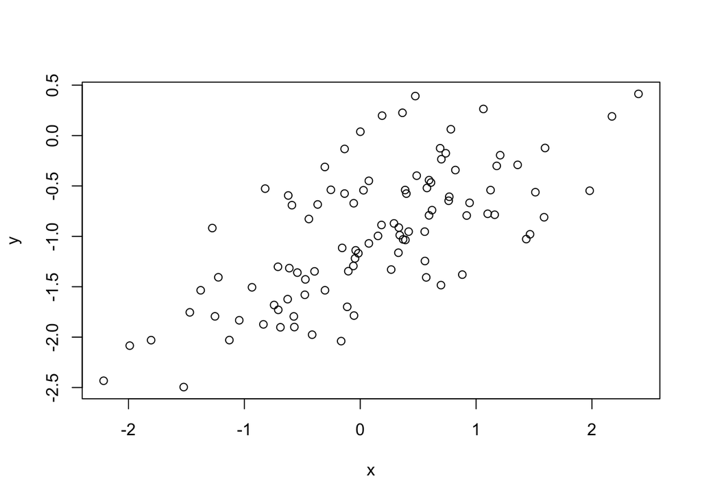

```r
plot(x,y)
```

There is a linear relationship between x and y with a slope of positive value and variance.

### (e)

```r
lm.fit = lm(y~x)
summary(lm.fit)
```

```
##
## Call:
## lm(formula = y ~ x)
##
## Residuals:
##      Min       1Q   Median       3Q      Max
## -0.93842 -0.30688 -0.06975  0.26970  1.17309
##
## Coefficients:
##             Estimate Std. Error t value Pr(>|t|)
## (Intercept) -1.01885    0.04849 -21.010  < 2e-16 ***
## x            0.49947    0.05386   9.273 4.58e-15 ***
## ---
## Signif. codes:  0 '***' 0.001 '**' 0.01 '*' 0.05 '.' 0.1 ' ' 1
##
## Residual standard error: 0.4814 on 98 degrees of freedom
## Multiple R-squared:  0.4674, Adjusted R-squared:  0.4619
## F-statistic: 85.99 on 1 and 98 DF,  p-value: 4.583e-15
```

The linear regression fits a model close to the true value of the coefficients as was constructed. The model has a large F-statistic and a near-zero p-value so the null hypothesis can be rejected.

### (f)

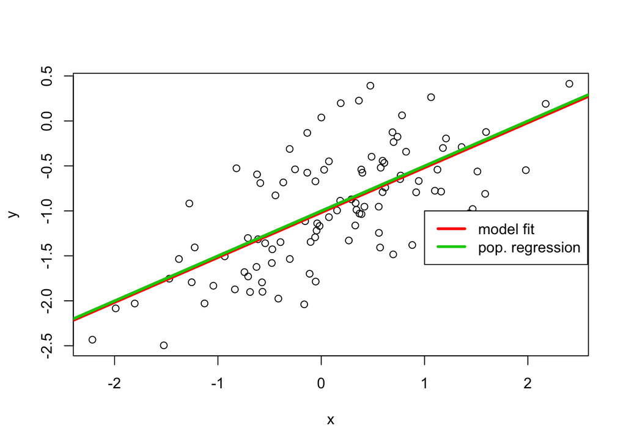

```r
plot(x,y)
abline(lm.fit, lwd=3, col=2)
abline(-1, 0.5, lwd=3, col=3)
legend(-1, legend = c("model fit", "pop. regression"), col=2:3, lwd=3)
```

### (g)

```r
lm.fit_sq = lm(y~x+I(x^2))
summary(lm.fit_sq)
```

```
##
## Call:
## lm(formula = y ~ x + I(x^2))
##
## Residuals:
##      Min       1Q   Median       3Q      Max
## -0.98252 -0.31270 -0.06441  0.29014  1.13500
##
## Coefficients:
##             Estimate Std. Error t value Pr(>|t|)
## (Intercept) -0.97164    0.05883 -16.517  < 2e-16 ***
## x            0.50858    0.05399   9.420  2.4e-15 ***
## I(x^2)      -0.05946    0.04238  -1.403    0.164
## ---
## Signif. codes:  0 '***' 0.001 '**' 0.01 '*' 0.05 '.' 0.1 ' ' 1
##
## Residual standard error: 0.479 on 97 degrees of freedom
## Multiple R-squared:  0.4779, Adjusted R-squared:  0.4672
## F-statistic:  44.4 on 2 and 97 DF,  p-value: 2.038e-14
```

There is evidence that this model fit increased given the slight increase in $R^2$ and decrease in $RSE$. Although, the p-value suggests that there isn’t a relationship between y and $x^2$.

### (h)

```r
set.seed(1)
eps1 = rnorm(100, 0, 0.125)
x1 = rnorm(100)
y1 = -1 + 0.5*x1 + eps1
plot(x1, y1)
lm.fit1 = lm(y1~x1)
summary(lm.fit1)
```

```
##
## Call:
## lm(formula = y1 ~ x1)
##
## Residuals:
##      Min       1Q   Median       3Q      Max
## -0.29052 -0.07545  0.00067  0.07288  0.28664
##
## Coefficients:
##             Estimate Std. Error t value Pr(>|t|)
## (Intercept) -0.98639    0.01129  -87.34   <2e-16 ***
## x1           0.49988    0.01184   42.22   <2e-16 ***
## ---
## Signif. codes:  0 '***' 0.001 '**' 0.01 '*' 0.05 '.' 0.1 ' ' 1
##
## Residual standard error: 0.1128 on 98 degrees of freedom
## Multiple R-squared:  0.9479, Adjusted R-squared:  0.9474
## F-statistic:  1782 on 1 and 98 DF,  p-value: < 2.2e-16
```

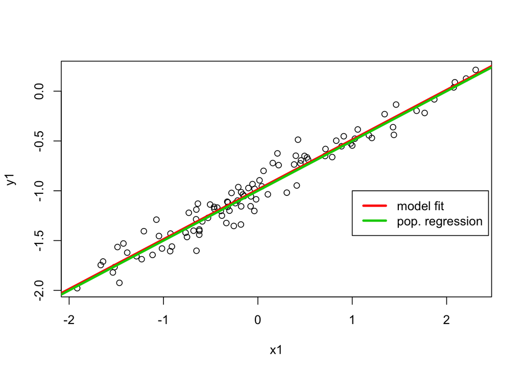

```r
abline(lm.fit1, lwd=3, col=2)
abline(-1, 0.5, lwd=3, col=3)
legend(-1, legend = c("model fit", "pop. regression"), col=2:3, lwd=3)
```

Observed $RSE$ decreased and $R^2$ increased.

### (i)

```r
set.seed(1)
eps2 = rnorm(100, 0, 0.8)
x2 = rnorm(100)
y2 = -1 + 0.5*x2 + eps2
plot(x2,y2)
lm.fit2 = lm(y2~x2)
summary(lm.fit2)
```

```
##
## Call:
## lm(formula = y2 ~ x2)
##
## Residuals:
##      Min       1Q   Median       3Q      Max
## -1.85933 -0.48289  0.00429  0.46644  1.83453
##
## Coefficients:
##             Estimate Std. Error t value Pr(>|t|)
## (Intercept) -0.91292    0.07228 -12.631  < 2e-16 ***
## x2           0.49925    0.07578   6.588 2.23e-09 ***
## ---
## Signif. codes:  0 '***' 0.001 '**' 0.01 '*' 0.05 '.' 0.1 ' ' 1
##
## Residual standard error: 0.7222 on 98 degrees of freedom
## Multiple R-squared:  0.307,  Adjusted R-squared:  0.2999
## F-statistic: 43.41 on 1 and 98 DF,  p-value: 2.235e-09
```

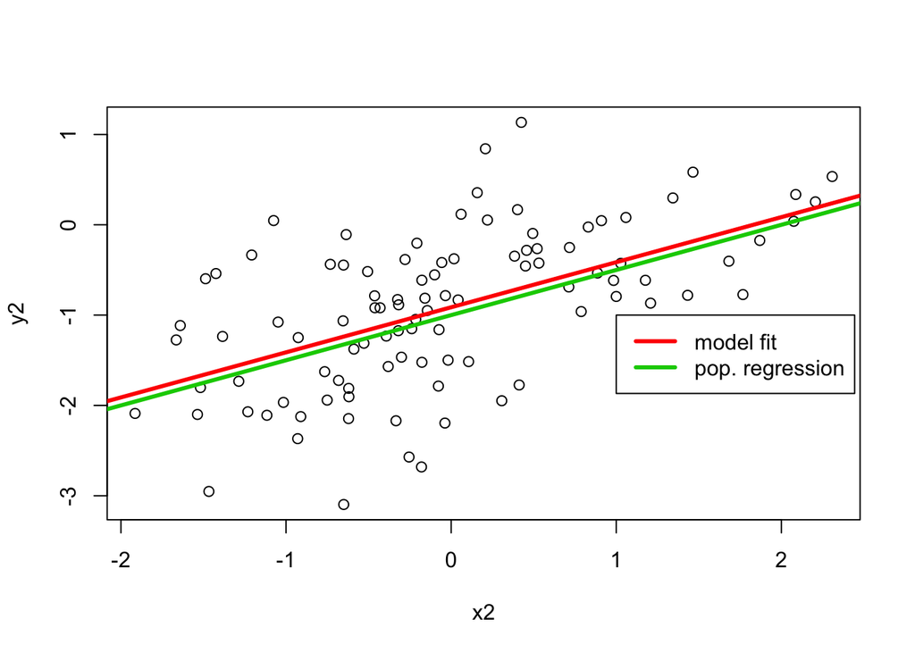

```r
abline(lm.fit2, lwd=3, col=2)
abline(-1, 0.5, lwd=3, col=3)
legend(-1, legend = c("model fit", "pop. regression"), col=2:3, lwd=3)
```

Observed $RSE$ increased and $R^2$ decreased.

### (j)

```r
confint(lm.fit)
```

```
##                  2.5 %     97.5 %
## (Intercept) -1.1150804 -0.9226122
## x            0.3925794  0.6063602
```

```r
confint(lm.fit1)
```

```
##                 2.5 %     97.5 %
## (Intercept) -1.008805 -0.9639819
## x1           0.476387  0.5233799
```

```r
confint(lm.fit2)
```

```
##                  2.5 %     97.5 %
## (Intercept) -1.0563524 -0.7694842
## x2           0.3488766  0.6496316
```

All intervals centered around 0.5. The interval of fit1 (less noisy) is narrower than that of fit (original). The interval of fit2 (noisier) is wider than that of fit (original).

## P4

```r
library(ISLR)
Advertising <- read.csv("http://www-bcf.usc.edu/~gareth/ISL/Advertising.csv",header=T,na.string=',')
#attach(Advertising)
model_newspaper = lm(sales~newspaper, data=Advertising)
model_TV = lm(sales~TV, data=Advertising)
model_radio = lm(sales~radio, data=Advertising)
confint(model_newspaper, , 0.92)
```

```
##                     4 %        96 %
## (Intercept) 11.25788302 13.44493112
## newspaper    0.02552451  0.08386169
```

```r
confint(model_TV, , 0.92)
```

```
##                    4 %       96 %
## (Intercept) 6.22691926 7.83826784
## TV          0.04280193 0.05227135
```

```r
confint(model_radio, , 0.92)
```

```
##                   4 %       96 %
## (Intercept) 8.3210922 10.3021840
## radio       0.1665776  0.2384139
```

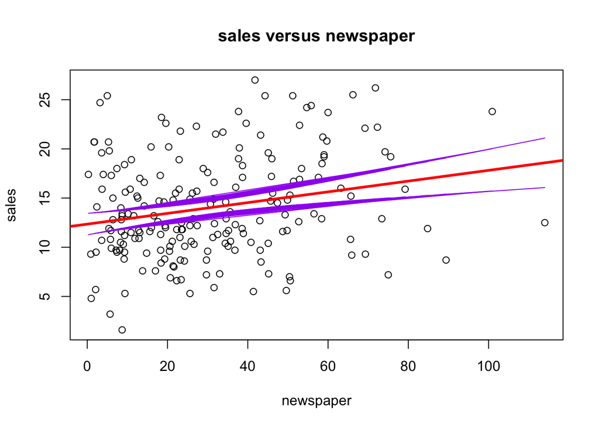

```r
plot(Advertising$newspaper,Advertising$sales, xlab = "newspaper", ylab = "sales", main = "sales versus newspaper")
abline(model_newspaper, lwd=3, col=2)
confint_newspaper = predict(model_newspaper, newspaper = data.frame(Advertising$newspaper), interval = "confidence", level=0.92)
lines(Advertising$newspaper, confint_newspaper[,2], col="purple")
lines(Advertising$newspaper, confint_newspaper[,3], col="purple")
```

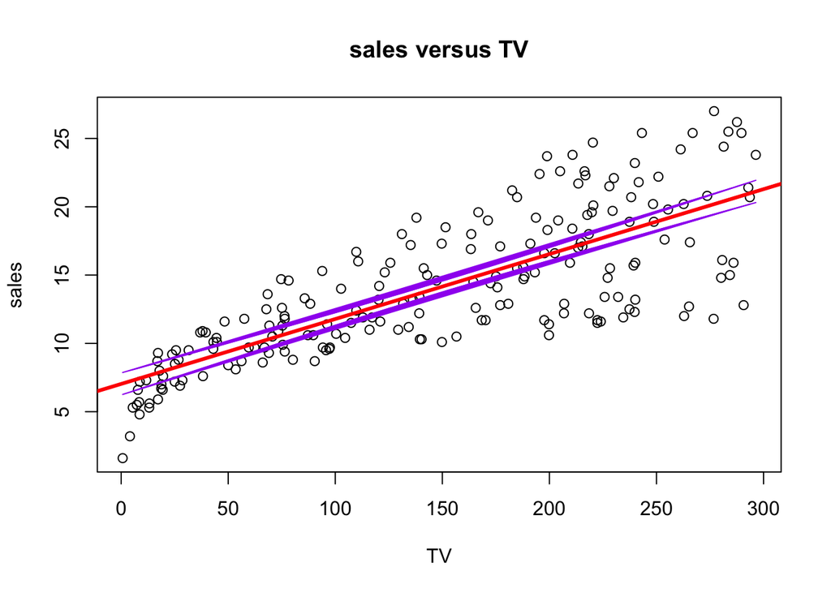

```r
plot(Advertising$TV,Advertising$sales, xlab = "TV", ylab = "sales", main = "sales versus TV")
abline(model_TV, lwd=3, col=2)
confint_TV = predict(model_TV, TV = data.frame(Advertising$TV), interval = "confidence", level=0.92)
lines(Advertising$TV, confint_TV[,2], col="purple")
lines(Advertising$TV, confint_TV[,3], col="purple")
```

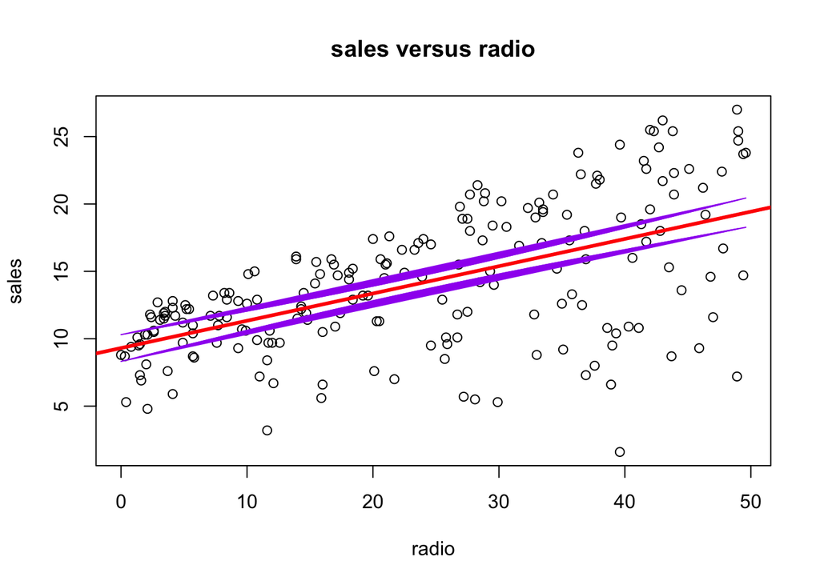

```r
plot(Advertising$radio,Advertising$sales, xlab = "radio", ylab = "sales", main = "sales versus radio")
abline(model_radio, lwd=3, col=2)
confint_radio = predict(model_radio, radio = data.frame(Advertising$radio), interval = "confidence", level=0.92)
lines(Advertising$radio, confint_radio[,2], col="purple")
lines(Advertising$radio, confint_radio[,3], col="purple")
```